# Trabalho_2_IA

### **Breast Cancer**

This data set contains information about breast cancer.  
Our objective will be to correctly predict if the event will have recurrence or not. This breast cancer domain was obtained from the University Medical Centre, Institute of Oncology, Ljubljana, Yugoslavia.

#### **Data Frame**

```python
# Header defined to the dataset as specified in UCI site
bc_header = [
    "class",
    "age",
    "menopause",
    "tumor-size",
    "inv-nodes",
    "node-caps",
    "deg-malig",
    "breast",
    "breast-quad",
    "irradiat"]

df_bc = pd.read_csv("breast-cancer.data", header=None, names=bc_header)
```

Here we can see what info we have on the raw data frame, and start to imagine what are going to be the next step.

```python
# Analising info about the dataframe
# As we can see, most of the data is written as objects
df_bc.info()
```

```
<class 'pandas.core.frame.DataFrame'>
RangeIndex: 286 entries, 0 to 285
Data columns (total 10 columns):
 #   Column       Non-Null Count  Dtype
---  ------       --------------  -----
 0   class        286 non-null    object
 1   age          286 non-null    object
 2   menopause    286 non-null    object
 3   tumor-size   286 non-null    object
 4   inv-nodes    286 non-null    object
 5   node-caps    286 non-null    object
 6   deg-malig    286 non-null    int64
 7   breast       286 non-null    object
 8   breast-quad  286 non-null    object
 9   irradiat     286 non-null    object
dtypes: int64(1), object(9)
memory usage: 22.5+ KB
```

Portion of the dataframe.

```python
df_bc.head()
```

|  | class | age | menopause | tumor-size | inv-nodes | node-caps | deg-malig | breast | breast-quad | irradiat |
| --- | --- | --- | --- | --- | --- | --- | --- | --- | --- | --- |
| 0 | no-recurrence-events | 30-39 | premeno | 30-34 | 0-2 | no | 3 | left | left_low | no |
| 1 | no-recurrence-events | 40-49 | premeno | 20-24 | 0-2 | no | 2 | right | right_up | no |
| 2 | no-recurrence-events | 40-49 | premeno | 20-24 | 0-2 | no | 2 | left | left_low | no |
| 3 | no-recurrence-events | 60-69 | ge40 | 15-19 | 0-2 | no | 2 | right | left_up | no |
| 4 | no-recurrence-events | 40-49 | premeno | 0-4 | 0-2 | no | 2 | right | right_low | no |

Code used to analize the different values from the dataset.

```python
## Commented to keep the output short

# for col in df_bc.columns:
#   print(df_bc[col].value_counts(), "\n\n")
```

#### **Pre-processing**

As we continue, there are a few procedures to make with the data before applying the models.

##### **Missing Data**

Ammount of data that is represented by '?', considered invalid.

```python
# Count ammount of invalid data
# For the database, Invalid is represented by '?'
invalid = 0
for col in df_bc.columns:
  invalid += df_bc[df_bc[col] == '?'].shape[0]
print(f"{100*(1- invalid/df_bc.shape[0]):.2f}% of non-invalid rows")
```

```
96.85% of non-invalid rows
```

As the ammount of invalid data isn't representative, the rows where just removed

```python
# Remove invalid values
for col in df_bc.columns:
  df_bc = df_bc[df_bc[col] != "?"]
```

##### **Database Normalization**

There are a few atributes on the dataset that cant be analised the way they are in the csv.  
On this step those atributes are ajusted and normalized to variables that can be used in models.

```python
# Used to analyse the data contained in the dataframe
# Comented to generate smaller report

# for col in df_bc.columns:
#   print(df_bc[col].value_counts(), "\n\n")
```

Based on this analysis we normalized the data values

```python
df_bc['age'] = df_bc["age"].replace(
    ["20-29","30-39","40-49","50-59","60-69","70-79"],
    [2,3,4,5,6,7]
)

df_bc["tumor-size"] = df_bc["tumor-size"].replace(
    ["0-4","5-9","10-14","15-19","20-24","25-29","30-34","35-39","40-44","45-49","50-54"],
    [1,2,3,4,5,6,7,8,9,10,11]
)

df_bc["inv-nodes"] = df_bc["inv-nodes"].replace(
    ["0-2","3-5","6-8","9-11","15-17","12-14","24-26"],
    [1,2,3,4,5,6,7]
)

df_bc["irradiat"] = df_bc["irradiat"].replace(
    ["no", "yes"],
    [False, True]
)

df_bc["node-caps"] = df_bc["node-caps"].replace(
    ["no", "yes"],
    [False, True]
)

df_bc["breast"] = df_bc["breast"].replace(
    ["left", "right"],
    [0, 1]
)

df_bc["menopause"] = df_bc["menopause"].replace(
    ["premeno", "lt40", "ge40"],
    [0, 1, 2]
)

df_bc['class'] = df_bc["class"].replace(
    ["no-recurrence-events", "recurrence-events"],
    [False, True]
)
```

##### **Atribute Selection**

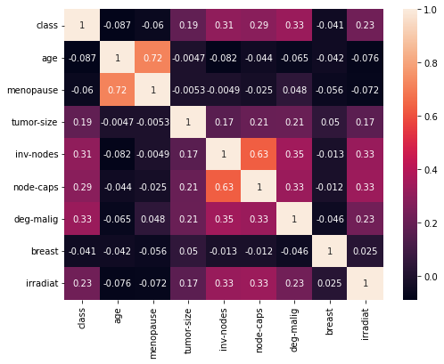

```python
# Plotting a heatmap with every value from the dataframe
# Used to compair correlations
f, ax = plt.subplots(figsize=(8, 6))
heatmap(df_bc.corr(), annot=True)
```

Analysing the data there are a few atributes that have weak correlation with the class, as:

- age
- menopause
- breast Beside those, the atribute of the quadrant is also going to be discarted

```python
# Droped the atributes to a new frame
df_res = df_bc.drop(["age", "menopause", "breast", "breast-quad"], axis=1)
df_res.info()
```

```
<class 'pandas.core.frame.DataFrame'>
Int64Index: 277 entries, 0 to 285
Data columns (total 6 columns):
 #   Column      Non-Null Count  Dtype
---  ------      --------------  -----
 0   class       277 non-null    bool
 1   tumor-size  277 non-null    int64
 2   inv-nodes   277 non-null    int64
 3   node-caps   277 non-null    bool
 4   deg-malig   277 non-null    int64
 5   irradiat    277 non-null    bool
dtypes: bool(3), int64(3)
memory usage: 9.5 KB
```

#### **Results**

##### **10-fold cross validation**

```python
# Suppress warnings and outputs
%%capture --no-stdout

# Separate between data and target classification
data, target = df_res.drop(columns=["class"]), LabelEncoder().fit_transform(df_res["class"])


# Test 10-fold cross validation for each one of the models
KNNaccuracy = cross_val_score(KNeighborsClassifier(), data, target, cv=10)
print(f"KNN Accuracy: {KNNaccuracy.mean():.4f} (+/- %{KNNaccuracy.std() * 2:.2f})")

DTaccuracy = cross_val_score(DecisionTreeClassifier(), data, target, cv=10)
print(f"DT Accuracy: {DTaccuracy.mean():.4f} (+/- %{DTaccuracy.std() * 2:.2f})")

MLPaccuracy = cross_val_score(MLPClassifier(), data, target, cv=10)
print(f"MLP Accuracy: {MLPaccuracy.mean():.4f} (+/- %{MLPaccuracy.std() * 2:.2f})")

NBaccuracy = cross_val_score(MultinomialNB(), data, target, cv=10)
print(f"NB Accuracy: {NBaccuracy.mean():.4f} (+/- %{NBaccuracy.std() * 2:.2f})")
```

```
KNN Accuracy: 0.6668 (+/- %0.24)
DT Accuracy: 0.6704 (+/- %0.19)
MLP Accuracy: 0.7067 (+/- %0.14)
NB Accuracy: 0.7327 (+/- %0.13)
```

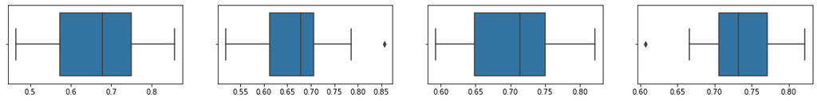

```python
# Supress plot warnings
%%capture --no-display
fig, axes = plt.subplots(1, 4, figsize=(20, 2))

## Boxplot chart plotting
boxplot(KNNaccuracy, ax=axes[0])
boxplot(DTaccuracy, ax=axes[1])
boxplot(MLPaccuracy, ax=axes[2])
boxplot(NBaccuracy, ax=axes[3])
```

```python
print(f"{abs_dif(NBaccuracy.mean(),NBaccuracy.std(),MLPaccuracy.mean(),MLPaccuracy.std()):.4f}")
```

```
0.3910
```

##### **Conclusion**

Pairplot chart to display clusters of the dataset.

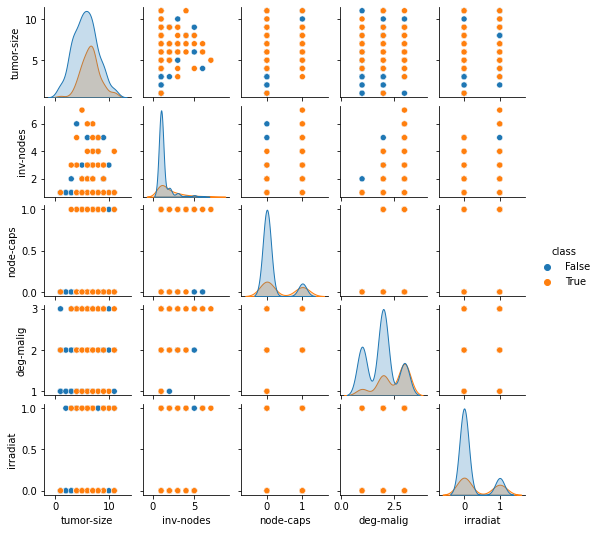

```python
# Had to modify a few data values to plot values
df_res['node-caps'] = df_res["node-caps"].replace(
    ["no", "yes"],
    [0, 1]
).astype(int)

df_res['irradiat'] = df_res["irradiat"].astype(int)


# Plotting pairplot
pairplot(df_res, hue="class", height=1.5)
```

As we can see in the charts, the dataset is not realy clustered between reincident and not reincident. This would explain the reason why the accuracy isn't high.  
Besides that, the 2 models that show best values to this dataset are Multi-layer Perceptron and Navian Bayes. Despite that, Navian Bayes has an accuracy slght better.

### **Mamographic Mass**

This data set can be used to predict the severity (benign or malignant) of a mammographic mass lesion from BI-RADS attributes and the patient's age.

#### **Data Frame**

```python
# Header defined to the dataset as specified in UCI site
mass_header = [
    "BI-RADS",
    "age",
    "shape",
    "margin",
    "density",
    "severity",
]

df_mass = pd.read_csv("mammographic_masses.data", header=None, names=mass_header)
```

```python
# We can see that the only non-numerical atribute is the class
# So, no treatment is needed
df_mass.info()
```

```
<class 'pandas.core.frame.DataFrame'>
RangeIndex: 961 entries, 0 to 960
Data columns (total 6 columns):
 #   Column    Non-Null Count  Dtype
---  ------    --------------  -----
 0   BI-RADS   961 non-null    object
 1   age       961 non-null    object
 2   shape     961 non-null    object
 3   margin    961 non-null    object
 4   density   961 non-null    object
 5   severity  961 non-null    int64
dtypes: int64(1), object(5)
memory usage: 45.2+ KB
```

Portion of the dataframe.

```python
df_mass.head()
```

|  | BI-RADS | age | shape | margin | density | severity |
| --- | --- | --- | --- | --- | --- | --- |
| 0 | 5 | 67 | 3 | 5 | 3 | 1 |
| 1 | 4 | 43 | 1 | 1 | ? | 1 |
| 2 | 5 | 58 | 4 | 5 | 3 | 1 |
| 3 | 4 | 28 | 1 | 1 | 3 | 0 |
| 4 | 5 | 74 | 1 | 5 | ? | 1 |

#### **Pre-processing**

As we continue, there are a few procedures to make with the data before applying the models.

##### **Missing Data**

Ammount of data that is represented by '?', considered invalid.

```python
# Count ammount of invalid data
# For the database, Invalid is represented by '?'
invalid = 0
for col in df_mass.columns:
  invalid += df_mass[df_mass[col] == '?'].shape[0]
print(f"{100*(1- invalid/df_mass.shape[0]):.2f}% of non-invalid rows")
```

```
83.14% of non-invalid rows
```

As the ammount of invalid data isn't representative, the rows where just removed

```python
# Remove invalid values
for col in df_mass.columns:
  df_mass = df_mass[df_mass[col] != "?"]
```

##### **Database Normalization**

There are a few atributes on the dataset that cant be analised the way they are in the csv.  
We could use the info values to verify we should just change the datatypes. On this step those atributes are ajusted and normalized to variables that can be used in models.

```python
# Converted each type to int or bool so i could model them
df_mass['BI-RADS'] = df_mass['BI-RADS'].astype(int)
df_mass['age'] = df_mass['age'].astype(int)
df_mass['shape'] = df_mass['shape'].astype(int)
df_mass['margin'] = df_mass['margin'].astype(int)
df_mass['density'] = df_mass['density'].astype(int)
df_mass['severity'] = df_mass['severity'].astype(bool)
```

##### **Atribute Selection**

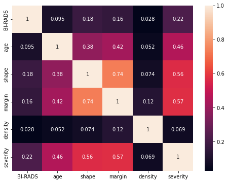

```python
# Heatmap of dataframe
f, ax = plt.subplots(figsize=(8, 6))
heatmap(df_mass.corr(), annot=True)
```

Analysing the data the only atribute that does not have a good correlation with severity is density

```python
df_res = df_mass.drop(["density"], axis=1)
```

#### **Result**

##### **10-fold cross validation**

```python
# Supress modeling warnings
%%capture --no-stdout

# Separate the data frame between numerical data and target classification
data, target = df_res.drop(columns=["severity"]), LabelEncoder().fit_transform(df_res["severity"])


# Each one of the modeling
KNNaccuracy = cross_val_score(KNeighborsClassifier(), data, target, cv=10)
print(f"KNN Accuracy: {KNNaccuracy.mean():.4f} (+/- %{KNNaccuracy.std() * 2:.2f})")

DTaccuracy = cross_val_score(DecisionTreeClassifier(), data, target,cv=10)
print(f"DT Accuracy: {DTaccuracy.mean():.4f} (+/- %{DTaccuracy.std() * 2:.2f})")

MLPaccuracy = cross_val_score(MLPClassifier(), data, target,cv=10)
print(f"MLP Accuracy: {MLPaccuracy.mean():.4f} (+/- %{MLPaccuracy.std() * 2:.2f})")

NBaccuracy = cross_val_score(MultinomialNB(), data, target,cv=10)
print(f"NB Accuracy: {NBaccuracy.mean():.4f} (+/- %{NBaccuracy.std() * 2:.2f})")
```

```
KNN Accuracy: 0.8072 (+/- %0.08)
DT Accuracy: 0.7892 (+/- %0.09)
MLP Accuracy: 0.7940 (+/- %0.09)
NB Accuracy: 0.7241 (+/- %0.08)
```

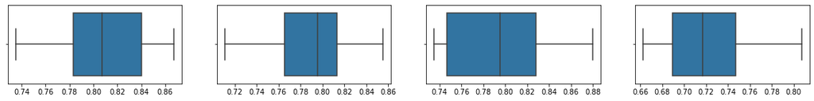

```python
# Supress plot warnings
%%capture --no-display
fig, axes = plt.subplots(1, 4, figsize=(20, 2))

## Boxplot chart plotting
boxplot(KNNaccuracy, ax=axes[0])
boxplot(DTaccuracy, ax=axes[1])
boxplot(MLPaccuracy, ax=axes[2])
boxplot(NBaccuracy, ax=axes[3])
```

```python
print(f"{abs_dif(KNNaccuracy.mean(),KNNaccuracy.std(),MLPaccuracy.mean(),MLPaccuracy.std()):.4f}")
```

```
0.3023
```

##### **Conclusion**

To display this data set we tried several different plots, but this one were the one that most called our attention. Analysing it we can estimate the severity of a mass based on the age and on the BI-RADS.

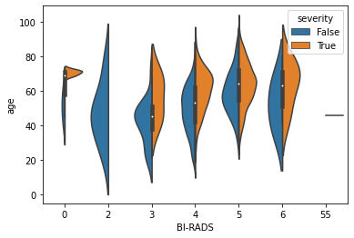

```python
sns.violinplot(data=df_res, hue="severity", x="BI-RADS", y="age", split=True)
```

Analysing this chart we can see that as bigger the BI-RADS greater the odds of an malignant severity.  
Despite that, as older the person the odds are also greater. A part from that, the models test had a good accuracy, highlighted to KNN.

## **Algorithms**

Short description about the algorithms we have used in this notebook.

#### **K-Nearest Neighbors**

The knn algorithm is based on the analysis of the data as points in a space. It get the classification based on the distance to the other points, called the 'nearest neighbors'.

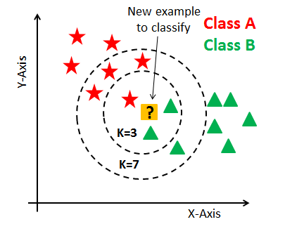

#### **Decision Tree**

In the DT classifier each node specifies a test on an attribute, and for each possible values for that attribute, it has a new a branch.  
To create the tree there is used a training data.

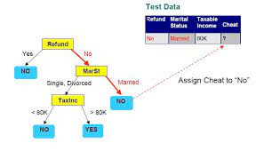

#### **Multinomial Navian Bayes**

Multinomial NB is a classification algorithm based on Bayes rule, that describes the Prior probability.  
Prior probability is analogue the conditional probability, but based on ocurrences and the values of it's classification.

#### **Multilayer Perceptron**

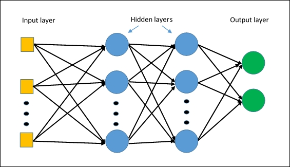